# Bayesian Regression modelling with brms

Michael Jones

2025-05-07

# Bayesian Primer

## Why Bayes?

- Philosophical: Probability can encode uncertainty
- Practical: use distributions
- Update beliefs based on data
- Do away with many different statistical tests
- Coherent system right up to complex non-linear models

## Why not Bayes?

- Slow(er) than Frequentist methods
- More computationally intensive
- Models might not converge
- Have to provide a prior
- Acceptance?

## What Bayes?

$$P(\theta|y) = \frac{P(y|\theta)P(\theta)}{P(y)}$$

## What Bayes?

$$P(\text{posterior}) = \frac{P(\text{likelihood})P(\text{prior})}{P(y)}$$

## What Bayes?

$$P(\text{posterior}) \propto {P(\text{likelihood})P(\text{prior})}$$

## How Bayes?

- *Pen and paper* conjugate priors
- *Computers* Markov Chain Monte Carlo: BUGS/JAGS with Metropolis Hastings and Gibbs Sampling or **Stan** with HMC and NUTS

# Regression Modelling Recap

## The humble `lm`

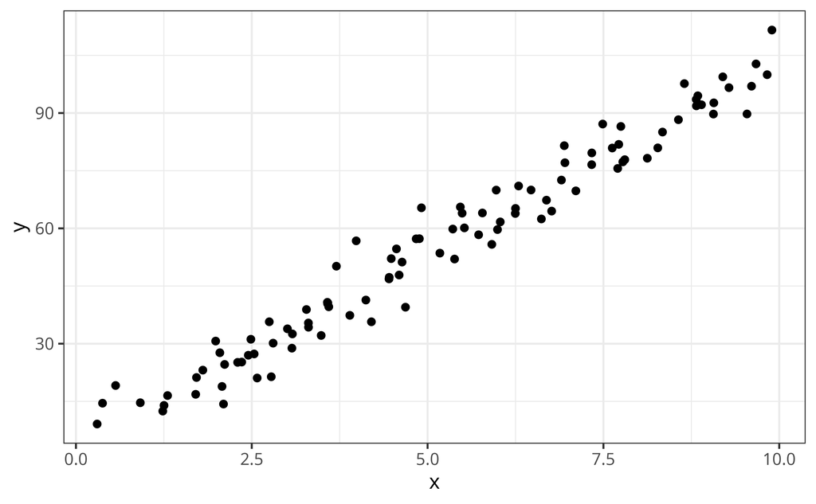

```r
set.seed(100)
fake_data <- tibble(x = runif(100, 0, 10),
                    y = 10 * x + 4 + rnorm(100, 0, 5))

ggplot(fake_data, aes(x = x, y = y)) + geom_point()
```

## The humble `lm`

```r
lm(y ~ x,
   data = fake_data)
```

```
Call:
lm(formula = y ~ x, data = fake_data)

Coefficients:
(Intercept)            x
      3.729        9.968
```

## The humble `lm`

```r
lm(y ~ x,
   data = fake_data)
```

```
Call:
lm(formula = y ~ x, data = fake_data)

Coefficients:
(Intercept)            x
      3.729        9.968
```

## The humble `lm`

```r
lm(y ~ x,
   data = fake_data)
```

```
Call:
lm(formula = y ~ x, data = fake_data)

Coefficients:
(Intercept)            x
      3.729        9.968
```

## Which of these are linear models?

$$\begin{align}
y &= \beta_0 + \beta_1 x\\
y &= \beta_0 + \beta_1 x_1 + \beta_2 x_2\\
y &= \exp(\beta_0 + \beta_1 x_1 + \beta_2 x_2)\\
y &= \beta_0 + \beta_1 x^2\\
y &= \beta_0 + \beta_1^2 x
\end{align}$$

## `lm` formula syntax

| formula | maths |
| --- | --- |
| `y ~ x` | $y = b_0 + b_1 x$ |
| `y ~ 1 + x` | $y = b_0 + b_1 x$ |
| `y ~ 0 + x` | $y = b_1 x$ |
| `y ~ x + y` | $y = b_0 + b_1 x + b_2 y$ |
| `y ~ x:y` | $y = b_0 + b_1 x y$ |
| `y ~ x*y` | $y = b_0 + b_1 x + b_2 y + b_3 x y$ |
| `y ~ I(x^2)` | $y = b_0 + b_1 x^2$ |

## Aside: linear models that aren’t a line

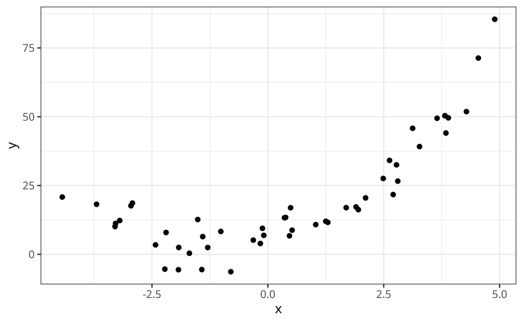

```r
set.seed(100)
quad_data <- tibble(
  x = runif(50, -5, 5),
  y = 2 * x^2 + 4*x + 5 + rnorm(50, sd = 5))

ggplot(quad_data, aes(x, y)) +
  geom_point()
```

## Aside: linear models that aren’t a line

```r
quad_mod <- lm(y ~ I(x^2) + x,
               data = quad_data)

quad_mod
```

```
Call:
lm(formula = y ~ I(x^2) + x, data = quad_data)

Coefficients:
(Intercept)       I(x^2)            x
      4.898        2.006        4.307
```

## Aside: linear models that aren’t a line

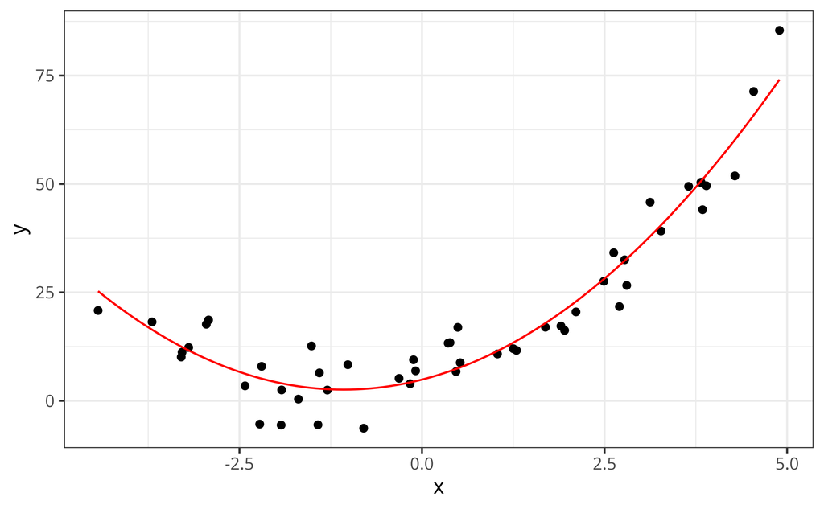

```r
b0 <- quad_mod$coefficients[1]
b1 <- quad_mod$coefficients[2]
b2 <- quad_mod$coefficients[3]
ggplot(quad_data, aes(x, y)) +
  geom_point() +
  geom_function(fun = \(x) b0 + x^2 * b1 + x * b2, colour = "red")
```

# brms

## What is brms?

- “Bayesian Regression Modelling in Stan”
- written by Paul Bürkner
- more on [CRAN](https://cran.r-project.org/web/packages/brms/)
- relies on [stan](https://mc-stan.org/)

## The stan family

[figure not shown]

## brms with R

[figure not shown]

## Side note: Sampling a Distribution

- **Objective**: Approximate a distribution
- **Problem**: You can ask what the value of this distribution is at any point, but you *only* get the value at that point
- **Solution**: Find a way to methodically sample (ask a lots of questions) in a way that your sample becomes representative. Bonus points if you can do so as efficiently as possible.

## Side note: Sampling a Distribution

- Pick a point, take the sample, record the result
- Pick some candidates, and accept one with some probability referencing your current value
- Jump to this new point
- Do this a lot to make a chain
- Improvements available including HMC

**Markov Chain Monte Carlo**

## My First Bayesian Model

```r
lm(y ~ x,
   data = fake_data)
```

```r
bmod1 <- brm(y ~ x,
             data = fake_data,
             family = gaussian(link = "identity"),
             backend = "cmdstanr",
             file = "my_first_model")
```

## My First Baysian Model

```r
y ~ x
```

$$\begin{align}
y &= \beta_0 + \beta_1 x + \epsilon\\
y &\sim \mathcal{N}(\beta_0 + \beta_1 x, \sigma^2)
\end{align}$$

## My First Bayesian Model

[output not shown]

## My First Bayesian Model

```
 Family: gaussian
  Links: mu = identity; sigma = identity
Formula: y ~ x
   Data: fake_data (Number of observations: 100)
  Draws: 4 chains, each with iter = 2000; warmup = 1000; thin = 1;
         total post-warmup draws = 4000

Regression Coefficients:
          Estimate Est.Error l-95% CI u-95% CI Rhat Bulk_ESS Tail_ESS
Intercept     3.71      1.14     1.51     5.95 1.00     3540     2793
x             9.97      0.20     9.58    10.36 1.00     3567     2746

Further Distributional Parameters:
      Estimate Est.Error l-95% CI u-95% CI Rhat Bulk_ESS Tail_ESS
sigma     5.13      0.38     4.47     5.92 1.00     3517     2585

Draws were sampled using sample(hmc). For each parameter, Bulk_ESS
and Tail_ESS are effective sample size measures, and Rhat is the potential
scale reduction factor on split chains (at convergence, Rhat = 1).
```

## My First Bayesian Model

```
 Family: gaussian
  Links: mu = identity; sigma = identity
Formula: y ~ x
   Data: fake_data (Number of observations: 100)
  Draws: 4 chains, each with iter = 2000; warmup = 1000; thin = 1;
         total post-warmup draws = 4000

Regression Coefficients:
          Estimate Est.Error l-95% CI u-95% CI Rhat Bulk_ESS Tail_ESS
Intercept     3.71      1.14     1.51     5.95 1.00     3540     2793
x             9.97      0.20     9.58    10.36 1.00     3567     2746

Further Distributional Parameters:
      Estimate Est.Error l-95% CI u-95% CI Rhat Bulk_ESS Tail_ESS
sigma     5.13      0.38     4.47     5.92 1.00     3517     2585

Draws were sampled using sample(hmc). For each parameter, Bulk_ESS
and Tail_ESS are effective sample size measures, and Rhat is the potential
scale reduction factor on split chains (at convergence, Rhat = 1).
```

## My First Bayesian Model

```
 Family: gaussian
  Links: mu = identity; sigma = identity
Formula: y ~ x
   Data: fake_data (Number of observations: 100)
  Draws: 4 chains, each with iter = 2000; warmup = 1000; thin = 1;
         total post-warmup draws = 4000

Regression Coefficients:
          Estimate Est.Error l-95% CI u-95% CI Rhat Bulk_ESS Tail_ESS
Intercept     3.71      1.14     1.51     5.95 1.00     3540     2793
x             9.97      0.20     9.58    10.36 1.00     3567     2746

Further Distributional Parameters:
      Estimate Est.Error l-95% CI u-95% CI Rhat Bulk_ESS Tail_ESS
sigma     5.13      0.38     4.47     5.92 1.00     3517     2585

Draws were sampled using sample(hmc). For each parameter, Bulk_ESS
and Tail_ESS are effective sample size measures, and Rhat is the potential
scale reduction factor on split chains (at convergence, Rhat = 1).
```

## My First Bayesian Model

```
 Family: gaussian
  Links: mu = identity; sigma = identity
Formula: y ~ x
   Data: fake_data (Number of observations: 100)
  Draws: 4 chains, each with iter = 2000; warmup = 1000; thin = 1;
         total post-warmup draws = 4000

Regression Coefficients:
          Estimate Est.Error l-95% CI u-95% CI Rhat Bulk_ESS Tail_ESS
Intercept     3.71      1.14     1.51     5.95 1.00     3540     2793
x             9.97      0.20     9.58    10.36 1.00     3567     2746

Further Distributional Parameters:
      Estimate Est.Error l-95% CI u-95% CI Rhat Bulk_ESS Tail_ESS
sigma     5.13      0.38     4.47     5.92 1.00     3517     2585

Draws were sampled using sample(hmc). For each parameter, Bulk_ESS
and Tail_ESS are effective sample size measures, and Rhat is the potential
scale reduction factor on split chains (at convergence, Rhat = 1).
```

## My First Bayesian Model

```
 Family: gaussian
  Links: mu = identity; sigma = identity
Formula: y ~ x
   Data: fake_data (Number of observations: 100)
  Draws: 4 chains, each with iter = 2000; warmup = 1000; thin = 1;
         total post-warmup draws = 4000

Regression Coefficients:
          Estimate Est.Error l-95% CI u-95% CI Rhat Bulk_ESS Tail_ESS
Intercept     3.71      1.14     1.51     5.95 1.00     3540     2793
x             9.97      0.20     9.58    10.36 1.00     3567     2746

Further Distributional Parameters:
      Estimate Est.Error l-95% CI u-95% CI Rhat Bulk_ESS Tail_ESS
sigma     5.13      0.38     4.47     5.92 1.00     3517     2585

Draws were sampled using sample(hmc). For each parameter, Bulk_ESS
and Tail_ESS are effective sample size measures, and Rhat is the potential
scale reduction factor on split chains (at convergence, Rhat = 1).
```

## My First Bayesian Model

```
 Family: gaussian
  Links: mu = identity; sigma = identity
Formula: y ~ x
   Data: fake_data (Number of observations: 100)
  Draws: 4 chains, each with iter = 2000; warmup = 1000; thin = 1;
         total post-warmup draws = 4000

Regression Coefficients:
          Estimate Est.Error l-95% CI u-95% CI Rhat Bulk_ESS Tail_ESS
Intercept     3.71      1.14     1.51     5.95 1.00     3540     2793
x             9.97      0.20     9.58    10.36 1.00     3567     2746

Further Distributional Parameters:
      Estimate Est.Error l-95% CI u-95% CI Rhat Bulk_ESS Tail_ESS
sigma     5.13      0.38     4.47     5.92 1.00     3517     2585

Draws were sampled using sample(hmc). For each parameter, Bulk_ESS
and Tail_ESS are effective sample size measures, and Rhat is the potential
scale reduction factor on split chains (at convergence, Rhat = 1).
```

## My First Bayesian Model

```
 Family: gaussian
  Links: mu = identity; sigma = identity
Formula: y ~ x
   Data: fake_data (Number of observations: 100)
  Draws: 4 chains, each with iter = 2000; warmup = 1000; thin = 1;
         total post-warmup draws = 4000

Regression Coefficients:
          Estimate Est.Error l-95% CI u-95% CI Rhat Bulk_ESS Tail_ESS
Intercept     3.71      1.14     1.51     5.95 1.00     3540     2793
x             9.97      0.20     9.58    10.36 1.00     3567     2746

Further Distributional Parameters:
      Estimate Est.Error l-95% CI u-95% CI Rhat Bulk_ESS Tail_ESS
sigma     5.13      0.38     4.47     5.92 1.00     3517     2585

Draws were sampled using sample(hmc). For each parameter, Bulk_ESS
and Tail_ESS are effective sample size measures, and Rhat is the potential
scale reduction factor on split chains (at convergence, Rhat = 1).
```

## My First Bayesian Model

```
 Family: gaussian
  Links: mu = identity; sigma = identity
Formula: y ~ x
   Data: fake_data (Number of observations: 100)
  Draws: 4 chains, each with iter = 2000; warmup = 1000; thin = 1;
         total post-warmup draws = 4000

Regression Coefficients:
          Estimate Est.Error l-95% CI u-95% CI Rhat Bulk_ESS Tail_ESS
Intercept     3.71      1.14     1.51     5.95 1.00     3540     2793
x             9.97      0.20     9.58    10.36 1.00     3567     2746

Further Distributional Parameters:
      Estimate Est.Error l-95% CI u-95% CI Rhat Bulk_ESS Tail_ESS
sigma     5.13      0.38     4.47     5.92 1.00     3517     2585

Draws were sampled using sample(hmc). For each parameter, Bulk_ESS
and Tail_ESS are effective sample size measures, and Rhat is the potential
scale reduction factor on split chains (at convergence, Rhat = 1).
```

## My First Bayesian Model - Hairy Caterpillars

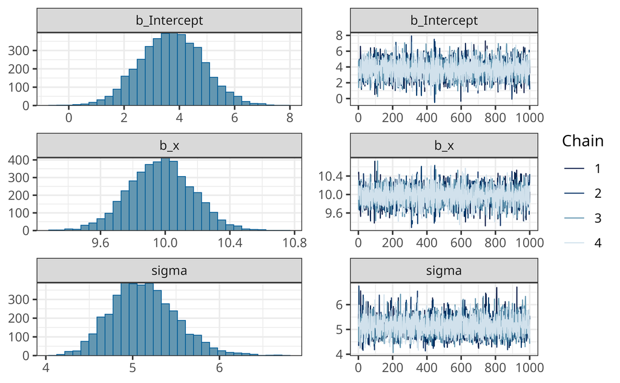

```r
plot(bmod1)
```

## My First Bayesian Model - PP Check

```r
pp_check(bmod1)
```

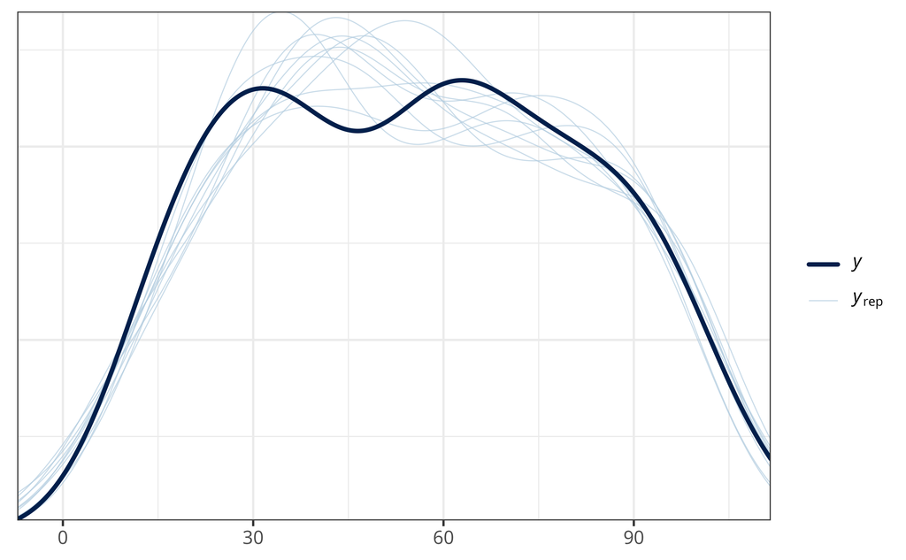

## My First Bayesian Model - Draws

```r
posterior::as_draws_df(bmod1)
```

```
# A draws_df: 1000 iterations, 4 chains, and 6 variables
   b_Intercept  b_x sigma Intercept lprior lp__
1          2.2 10.4   5.4        57   -8.4 -315
2          2.0 10.5   5.6        57   -8.4 -315
3          2.3 10.3   5.6        56   -8.4 -312
4          2.3 10.3   4.6        56   -8.4 -312
5          3.1 10.1   5.2        56   -8.4 -311
6          4.0  9.8   4.8        55   -8.4 -311
7          3.6 10.1   5.2        56   -8.4 -310
8          2.3 10.3   5.0        56   -8.4 -311
9          3.8 10.0   5.5        56   -8.4 -311
10         5.0  9.7   4.8        56   -8.4 -311
# ... with 3990 more draws
# ... hidden reserved variables {'.chain', '.iteration', '.draw'}
```

## My First Bayesian Model - Draws

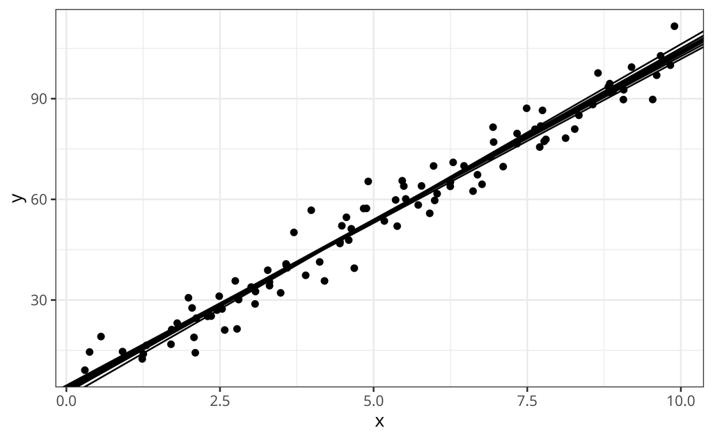

```r
posterior::as_draws_df(bmod1) |>
  slice_sample(n = 10) |>
  ggplot() +
  geom_abline(mapping = aes(intercept = b_Intercept,
                            slope = b_x)) +
  geom_point(data = fake_data, mapping = aes(x = x, y = y))
```

# Other Models

## Robust Regression

- reach for ridge or lasso regression
- Bayesian way: model the errors with a student-t distribution rather than a gaussian

## Binomial Data (coin flips etc)

```r
coin_data <- tibble(flips = 50, heads = 10)
bmod_coin <- brm(
  heads | trials(flips) ~ 1,
  data = coin_data,
  family = binomial(link = "logit"),
  backend = "cmdstanr",
  file = "coins"
)
```

## Coin Flips

```r
bmod_coin
```

```
 Family: binomial
  Links: mu = logit
Formula: heads | trials(flips) ~ 1
   Data: coin_data (Number of observations: 1)
  Draws: 4 chains, each with iter = 2000; warmup = 1000; thin = 1;
         total post-warmup draws = 4000

Regression Coefficients:
          Estimate Est.Error l-95% CI u-95% CI Rhat Bulk_ESS Tail_ESS
Intercept    -1.39      0.35    -2.10    -0.75 1.00     1425     1578

Draws were sampled using sample(hmc). For each parameter, Bulk_ESS
and Tail_ESS are effective sample size measures, and Rhat is the potential
scale reduction factor on split chains (at convergence, Rhat = 1).
```

## Coin Flips

```r
inv_logit_scaled(fixef(bmod_coin)[1])
```

```
[1] 0.200066
```

```r
10/50
```

```
[1] 0.2
```

## Coin Flips

```r
bayesplot::mcmc_areas(
  bmod_coin,
  pars = "b_Intercept", # we only want to plot the Intercept parameter
  transformations = inv_logit_scaled) # convert to probability space
```

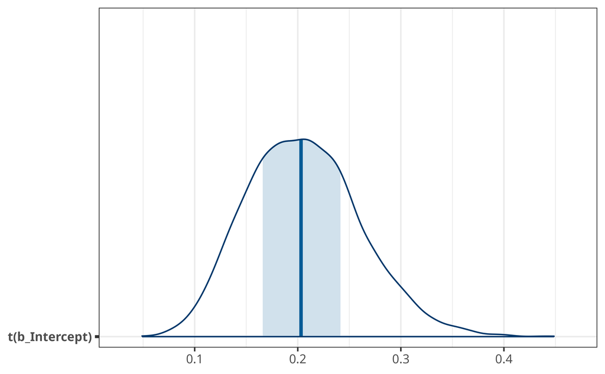

## Side note: Beta Priors

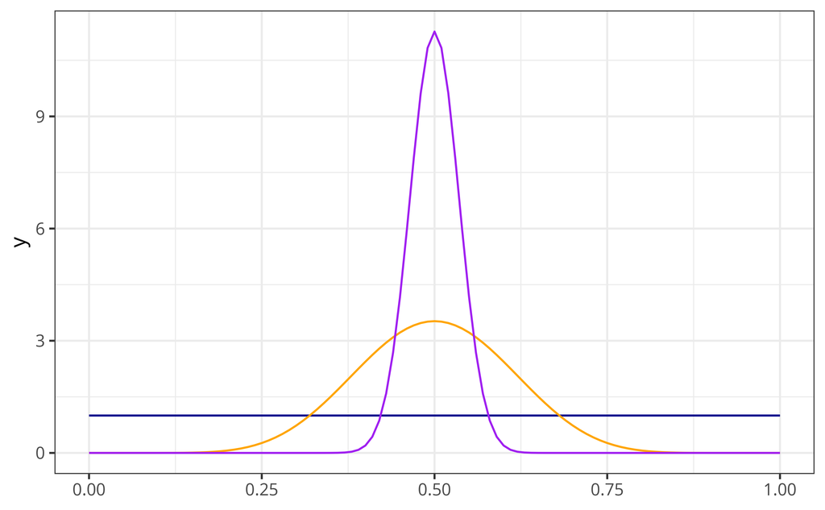

```r
ggplot() +
  geom_function(fun = \(x) dbeta(x, shape1 = 1, shape2 = 1), colour = "darkblue") +
  geom_function(fun = \(x) dbeta(x, shape1 = 10, shape2 = 10), colour = "orange") +
  geom_function(fun = \(x) dbeta(x, shape1 = 100, shape2 = 100), colour = "purple")
```

## Coin Flips with priors

```r
bmod_coin_weak <- brm(
  heads | trials(flips) ~ 1,
  data = coin_data,
  prior = prior(beta(2, 2), class = "Intercept"), # <--
  family = binomial(link = "identity"),
  backend = "cmdstanr",
  file = "coins_weak"
)

bmod_coin_strong <- brm(
  heads | trials(flips) ~ 1,
  data = coin_data,
  prior = prior(beta(100, 100), class = "Intercept"), # <--
  family = binomial(link = "identity"),
  backend = "cmdstanr",
  file = "coins_strong"
)
```

## Coin Flips with weak prior

```r
bmod_coin_weak
```

```
 Family: binomial
  Links: mu = identity
Formula: heads | trials(flips) ~ 1
   Data: coin_data (Number of observations: 1)
  Draws: 4 chains, each with iter = 2000; warmup = 1000; thin = 1;
         total post-warmup draws = 4000

Regression Coefficients:
          Estimate Est.Error l-95% CI u-95% CI Rhat Bulk_ESS Tail_ESS
Intercept     0.22      0.05     0.12     0.34 1.00     1299     1416

Draws were sampled using sample(hmc). For each parameter, Bulk_ESS
and Tail_ESS are effective sample size measures, and Rhat is the potential
scale reduction factor on split chains (at convergence, Rhat = 1).
```

## Coin Flips with Strong Prior

```r
bmod_coin_strong
```

```
 Family: binomial
  Links: mu = identity
Formula: heads | trials(flips) ~ 1
   Data: coin_data (Number of observations: 1)
  Draws: 4 chains, each with iter = 2000; warmup = 1000; thin = 1;
         total post-warmup draws = 4000

Regression Coefficients:
          Estimate Est.Error l-95% CI u-95% CI Rhat Bulk_ESS Tail_ESS
Intercept     0.44      0.03     0.38     0.50 1.00     1464     1870

Draws were sampled using sample(hmc). For each parameter, Bulk_ESS
and Tail_ESS are effective sample size measures, and Rhat is the potential
scale reduction factor on split chains (at convergence, Rhat = 1).
```

## Comparison

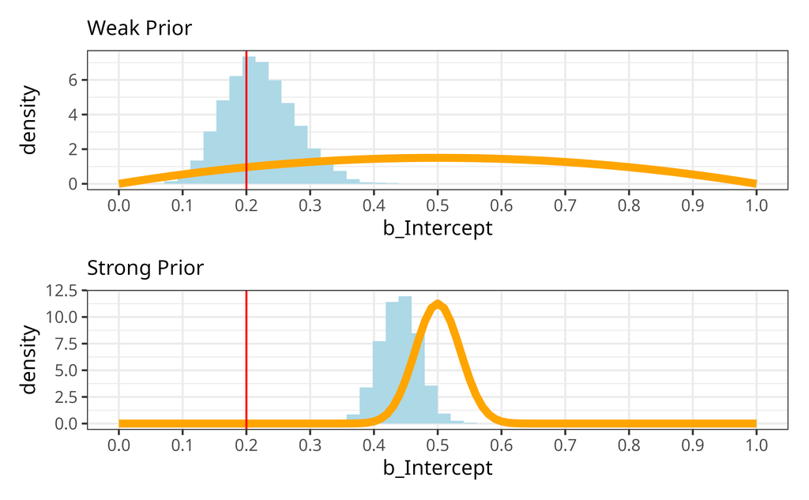

# Multilevel Models

## Multilevel Models

- Reflect *hierarchical* structure of your problem domain
- There’s some variation at a population level
- Also some variation within sub entities
- You want to share uncertainty/information between these levels

## Multilevel Models

Extension to the formula:

```
y ~ p + (r | g)
```

- `p`: population level effects
- `r`: ‘random’ effects, i.e. group level effects
- `g`: grouping variable

## Multilevel Models

[figure not shown]

## Multilevel Models

```r
bmod_iris <- brm(
  Petal.Length ~ 1 + Sepal.Length + (1 + Sepal.Length | Species),
  data = iris,
  backend = "cmdstanr",
  file = "multilevel")
```

## Multilevel Models

```
 Family: gaussian
  Links: mu = identity; sigma = identity
Formula: Petal.Length ~ 1 + Sepal.Length + (1 + Sepal.Length | Species)
   Data: iris (Number of observations: 150)
  Draws: 4 chains, each with iter = 2000; warmup = 1000; thin = 1;
         total post-warmup draws = 4000

Multilevel Hyperparameters:
~Species (Number of levels: 3)
                            Estimate Est.Error l-95% CI u-95% CI Rhat Bulk_ESS Tail_ESS
sd(Intercept)                   0.64      0.69     0.02     2.39 1.01      495      771
sd(Sepal.Length)                0.53      0.28     0.18     1.24 1.01      578      785
cor(Intercept,Sepal.Length)    -0.05      0.60    -0.97     0.95 1.00      634     1171
```

## Multilevel Models

```
Regression Coefficients:
             Estimate Est.Error l-95% CI u-95% CI Rhat Bulk_ESS Tail_ESS
Intercept        0.53      0.54    -0.46     2.02 1.01      376      132
Sepal.Length     0.59      0.24     0.12     1.12 1.01      660      589

Further Distributional Parameters:
      Estimate Est.Error l-95% CI u-95% CI Rhat Bulk_ESS Tail_ESS
sigma     0.26      0.02     0.23     0.30 1.01     1138      833

Draws were sampled using sample(hmc). For each parameter, Bulk_ESS
and Tail_ESS are effective sample size measures, and Rhat is the potential
scale reduction factor on split chains (at convergence, Rhat = 1).
```

## Multilevel Models

```r
fixef(bmod_iris)
```

```
              Estimate Est.Error       Q2.5    Q97.5
Intercept    0.5318709 0.5396609 -0.4638470 2.023480
Sepal.Length 0.5873578 0.2442129  0.1190371 1.115754
```

```r
ranef(bmod_iris)
```

```
$Species
, , Intercept

              Estimate Est.Error      Q2.5     Q97.5
setosa      0.06899166 0.5537010 -1.256369 1.2012115
versicolor -0.15903353 0.5497306 -1.704974 0.8129511
virginica   0.02431809 0.4968133 -1.320186 1.0449123

, , Sepal.Length

              Estimate Est.Error       Q2.5      Q97.5
setosa     -0.41549242 0.2556132 -0.9461325 0.05927435
versicolor  0.06777262 0.2430173 -0.4618805 0.52713793
virginica   0.17090787 0.2443261 -0.3543854 0.64513015
```

## Multilevel Models

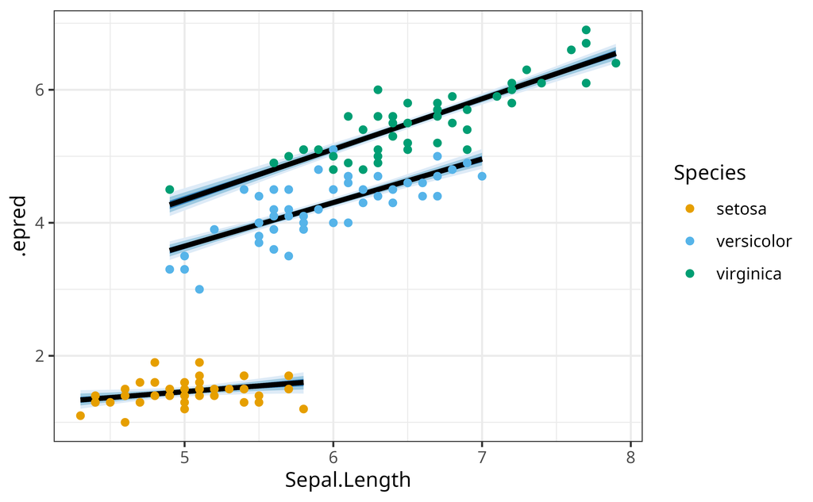

## Prediction

```r
new_data <- tibble(Species = "setosa", Sepal.Length = 7)
(predictions <- tidybayes::add_epred_draws(bmod_iris,
                                           newdata = new_data))
```

```
# A tibble: 4,000 × 7
# Groups:   Species, Sepal.Length, .row [1]
   Species Sepal.Length  .row .chain .iteration .draw .epred
   <chr>          <dbl> <int>  <int>      <int> <int>  <dbl>
 1 setosa             7     1     NA         NA     1   1.77
 2 setosa             7     1     NA         NA     2   1.68
 3 setosa             7     1     NA         NA     3   1.62
 4 setosa             7     1     NA         NA     4   1.59
 5 setosa             7     1     NA         NA     5   1.91
 6 setosa             7     1     NA         NA     6   1.59
 7 setosa             7     1     NA         NA     7   1.61
 8 setosa             7     1     NA         NA     8   1.70
 9 setosa             7     1     NA         NA     9   1.81
10 setosa             7     1     NA         NA    10   1.75
# ℹ 3,990 more rows
```

## Prediction

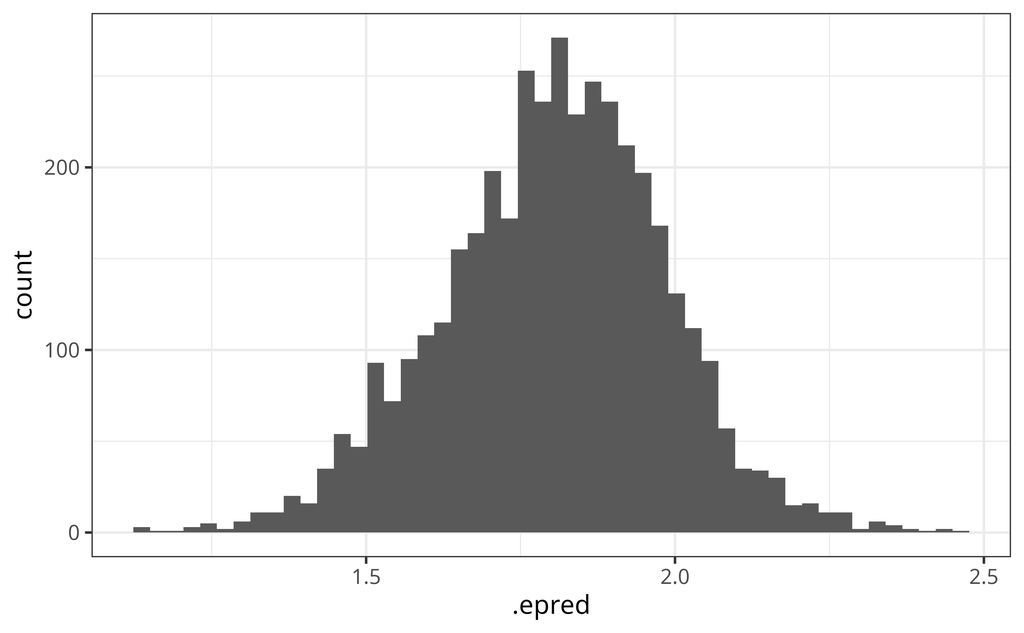

```r
as_tibble(predictions) |>
  ggplot(aes(x = .epred)) +
  geom_histogram(bins = 50)
```

## Predictions

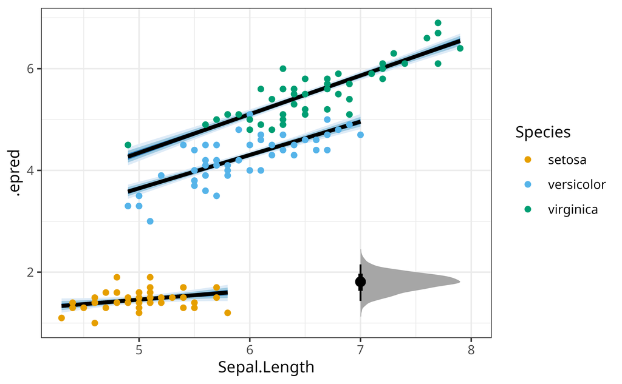

# Other Models

## Too Many Zeros

- More zeros than expected in the data
- **Hurdle models**: if $p < h$ then zero, otherwise (non-zero) value from other distribution
- **Zero-inflated**: a mixture of models, e.g. some probability of getting zero, and some probability of getting a draw from a normal, e.g. poisson.

## Too Many Zeros

Fake data: 20% chance of generating a value from a log normal distribution:

```r
set.seed(1000)
p_lnorm <- 0.2
n <- 100

fake_hurdle_data <- tibble(
  r = runif(n),
  x = if_else(r < 0.2, rlnorm(n, meanlog = 4, sdlog = 4), 0))
```

## Too Many Zeros

```r
bmod_hurdle <-
  brm(x ~ 1,
      fake_hurdle_data,
      family = hurdle_lognormal(),
      backend = "cmdstanr",
      file = "hurdle")
```

## Too Many Zeros

```r
bmod_hurdle
```

```
 Family: hurdle_lognormal
  Links: mu = identity; sigma = identity; hu = identity
Formula: x ~ 1
   Data: fake_hurdle_data (Number of observations: 100)
  Draws: 4 chains, each with iter = 2000; warmup = 1000; thin = 1;
         total post-warmup draws = 4000

Regression Coefficients:
          Estimate Est.Error l-95% CI u-95% CI Rhat Bulk_ESS Tail_ESS
Intercept     4.32      0.70     3.00     5.69 1.00     3163     2520

Further Distributional Parameters:
      Estimate Est.Error l-95% CI u-95% CI Rhat Bulk_ESS Tail_ESS
sigma     3.35      0.51     2.54     4.49 1.00     2954     2224
hu        0.75      0.04     0.67     0.83 1.00     3606     3052

Draws were sampled using sample(hmc). For each parameter, Bulk_ESS
and Tail_ESS are effective sample size measures, and Rhat is the potential
scale reduction factor on split chains (at convergence, Rhat = 1).
```

# Learn More

## Resources

- [Doing Bayesian Data Analysis](https://sites.google.com/site/doingbayesiandataanalysis/) John K Kruschke
- [Statistical Rethinking](https://xcelab.net/rm/) Richard McElreath (plus YouTube/GitHub resources)
- [Solomon Kurz’s work rewriting books in brms](https://bookdown.org/content/4857/)
- [Regression and Other Stories](https://avehtari.github.io/ROS-Examples/index.html) Gelman, Hill, Vehtari

## Resources

- [Andrew Heiss’s Blog](https://www.andrewheiss.com/blog/)
- [BDA3](https://sites.stat.columbia.edu/gelman/book/)
- [brms Vignettes](https://cran.r-project.org/web/packages/brms/index.html)

## Next Steps

- install `brms`
- if Windows, get [RTools](https://cran.r-project.org/bin/windows/Rtools/) for compilers etc
- install [cmdstanr](https://mc-stan.org/cmdstanr/) and follow the instructions
- Dip into stan?

## Bonus: Stan code

```r
bmod1 |> stancode()
```

```
// generated with brms 2.22.0
functions {
}
data {
  int<lower=1> N;  // total number of observations
  vector[N] Y;  // response variable
  int<lower=1> K;  // number of population-level effects
  matrix[N, K] X;  // population-level design matrix
  int<lower=1> Kc;  // number of population-level effects after centering
  int prior_only;  // should the likelihood be ignored?
}
transformed data {
  matrix[N, Kc] Xc;  // centered version of X without an intercept
  vector[Kc] means_X;  // column means of X before centering
  for (i in 2:K) {
    means_X[i - 1] = mean(X[, i]);
    Xc[, i - 1] = X[, i] - means_X[i - 1];
  }
}
parameters {
  vector[Kc] b;  // regression coefficients
  real Intercept;  // temporary intercept for centered predictors
  real<lower=0> sigma;  // dispersion parameter
}
transformed parameters {
  real lprior = 0;  // prior contributions to the log posterior
  lprior += student_t_lpdf(Intercept | 3, 57, 33.6);
  lprior += student_t_lpdf(sigma | 3, 0, 33.6)
    - 1 * student_t_lccdf(0 | 3, 0, 33.6);
}
model {
  // likelihood including constants
  if (!prior_only) {
    target += normal_id_glm_lpdf(Y | Xc, Intercept, b, sigma);
  }
  // priors including constants
  target += lprior;
}
generated quantities {
  // actual population-level intercept
  real b_Intercept = Intercept - dot_product(means_X, b);
}
```